**Computational Thinking**

|  | By Seungchul Lee http://isystems.unist.ac.kr/ UNIST |
| --- | --- |

Table of Contents

# 1. Fixed-Point Iteration

## 1.1. Numerical approach

For the given equation:

$$f(x) = 0 \implies x = g(x)$$

Remark: always achievable

$$ \begin{align*} x & = f(x) + x = g(x)\\ x &= -f(x) + x = g(x) \end{align*} $$

Goal: *numerically* find the solution of $x = g(x)$

Main idea:

- Make a guess of the solution, $x_k$
- If $g(x_k)$ is 'nice', then hopefully, $g(x_k)$ will be closer to the answer. If so, we can iterate

**Iteration algorithm**

1. choose an initial point $x_0$
2. Do the iteration $x_{k+1} = g(x_k)$ unitl meeting stop criteria

**Convergence check (or analysis)**

$\quad$ Let $r$ be the exact solution, $r = g(r)$

$$ \begin{array}{l} x_{k+1} &= g(x_k)\\ \text{error} :&\quad e_k &= x_k - r\\ &\quad e_{k+1} &= x_{k+1} - r = g(x_k) - g(r)\\ &&= g'(\eta)(x_k - r) = g'(\eta)e_k , \quad \eta \in (x_k, r)\\ \\ &\implies \lvert e_{k+1}\rvert &\leq \lvert g'(\eta)\rvert \lvert e_k \rvert\\ \end{array} $$

$$\text{If } \lvert g'(\eta) \rvert <1, \text{error decreases (iteration converges)}$$

**Example of $x = \cos(x)$**

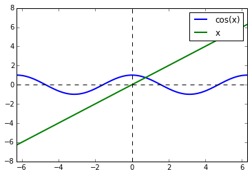

```python
# Computational Thinking on how to calculate cos(x) = x

import numpy as np
import matplotlib.pyplot as plt
% matplotlib inline

x = np.linspace(-2*np.pi, 2*np.pi, 100)
y = np.cos(x)

plt.plot(x, y, linewidth = 2)
plt.plot(x, x, linewidth = 2)
plt.xlim(-2*np.pi, 2*np.pi)
plt.axvline(x=0, color = 'k', linestyle = '--')
plt.axhline(y=0, color = 'k', linestyle = '--')
plt.legend(['cos(x)','x'])
plt.show()
```

```python
# naive approach

x = 0.3
print (np.cos(x))
print (np.cos(np.cos(x)))
print (np.cos(np.cos(np.cos(x))))
print (np.cos(np.cos(np.cos(np.cos(x)))))
print (np.cos(np.cos(np.cos(np.cos(np.cos(x))))))
print (np.cos(np.cos(np.cos(np.cos(np.cos(np.cos(x)))))))
print (np.cos(np.cos(np.cos(np.cos(np.cos(np.cos(np.cos(x))))))))
```

```
0.955336489126
0.577334044471
0.837920683127
0.669009730822
0.784436224742
0.707786647276
0.759802755285
```

```python
# better way

x = 0.3

for i in range(20):
    tmp = np.cos(x)
    x = np.cos(tmp)

print (x)
```

```
0.739085087856
```

```python
# better way

x = np.zeros((24, 1))
x[0] = 0.3

for i in range(23):
    x[i+1] = np.cos(x[i])

print (x)
```

```
[[ 0.3       ]
 [ 0.95533649]
 [ 0.57733404]
 [ 0.83792068]
 [ 0.66900973]
 [ 0.78443622]
 [ 0.70778665]
 [ 0.75980276]
 [ 0.72497188]
 [ 0.74851807]
 [ 0.73269821]
 [ 0.74337234]
 [ 0.73619044]
 [ 0.74103194]
 [ 0.73777234]
 [ 0.73996881]
 [ 0.73848959]
 [ 0.73948617]
 [ 0.73881493]
 [ 0.73926712]
 [ 0.73896253]
 [ 0.73916771]
 [ 0.73902951]
 [ 0.7391226 ]]
```

```python
x = 10
for i in range(24):
    x = np.cos(x)

print (x)
```

```
0.739073544468
```

```python
% matplotlib qt
# result display

x = 0.3

ps = 0.3
t = np.arange(0,1.2,0.01)

plt.plot(t, t, 'k')
plt.plot(t, np.cos(t), 'k')
plt.plot([x, x], [0, np.cos(x)], 'r:')
plt.xlim([0, 1.2])
plt.ylim([0, 1.2])
plt.plot(x, np.cos(x), 'bo')
plt.pause(ps)
for i in range(9):
    plt.plot([x,np.cos(x)],[np.cos(x),np.cos(x)],'r:')
    plt.pause(ps)
    plt.plot([np.cos(x),np.cos(x)],[np.cos(x),np.cos(np.cos(x))],'r:')
    x = np.cos(x);
    plt.plot(x,np.cos(x),'bo')

    plt.pause(ps)
```

## 1.2. Newton's Method

Goal: Given $f(x)$, find a root $x^*$ such that $f(x^*)=0$

Once we have $x_k$, the next approximation $x_{k+1}$ is given

$$ x_{k+1} \leftarrow x_k - \frac{f(x_k)}{f'(x_k)} $$

- Graphical interpretation

[figure not shown]

- View it as a fixed point iteration

$$ x_{k+1}=g(x_k), \quad g(x) = x-\frac{f(x_k)}{f'(x_k)} $$

If $x^*$ ia s fixed point,

$$ x^* = g(x^*) = x^* - \frac{f(x^*)}{f'(x^*)} \implies f(x^*)=0 \quad \text{if}\; f'(x^*) \neq 0$$

```python
# Newton's Method

x = 0.1

for i in range(10):
    x = x - (np.cos(x)- x)/(-np.sin(x) - 1)

print(x)
```

```
0.739085133215
```

```
0.739085133215
```

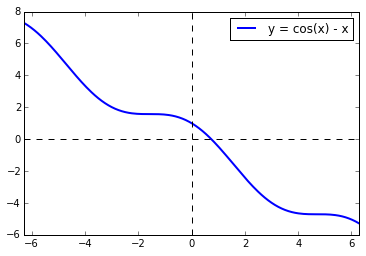

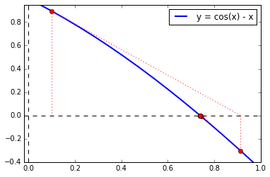

```python
% matplotlib inline
# result display

x = np.linspace(-2*np.pi, 2*np.pi, 200)
y = np.cos(x) - x

plt.figure(2)
plt.plot(x, y, linewidth = 2)
plt.xlim(-2*np.pi, 2*np.pi)
plt.axvline(x=0, color = 'k', linestyle = '--')
plt.axhline(y=0, color = 'k', linestyle = '--')
plt.legend(['y = cos(x) - x'])

plt.figure(3)
plt.plot(x, y, linewidth = 2)
plt.axvline(x=0, color = 'k', linestyle = '--')
plt.axhline(y=0, color = 'k', linestyle = '--')
plt.legend(['y = cos(x) - x'])

x = 0.1 # initial guess
for i in range(10):
    plt.plot(x, np.cos(x)-x, 'ro')
    plt.plot([x, x], [0, np.cos(x)-x], 'r:')
    x_next = x - (np.cos(x) - x)/(-np.sin(x)-1)
    plt.plot([x, x_next], [np.cos(x)-x, 0], 'r:')
    x = x_next
plt.xlim([-0.02, 1])
plt.ylim([-0.4, 0.95])

print(x)
```

**example of $\sqrt{2} \;(x^2 = 2)$**

```python
# Use an idea of a fixed point
x = 2
for i in range(10):
    x = 2/x

print (x)
```

```
2
```

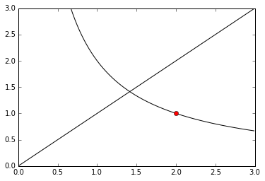

```python
# Graphical Explanation (oscillating)

%matplotlib qt
t = np.arange(0, 3, 0.01)
x = 2
plt.figure(1)
for i in range(10):
    plt.clf()
    h = plt.plot(t,t,'k',t,2/t,'k',x,2/x,'ro');
    plt.xlim([0, 3])
    plt.ylim([0, 3])
    x = 2/x
    plt.pause(0.5)
% matplotlib inline
h = plt.plot(t,t,'k',t,2/t,'k',x,2/x,'ro');
plt.xlim([0, 3])
plt.ylim([0, 3])
plt.show()
```

```python
# How to overcome
# Use an idea of a fixed point + kind of *|damping|*

x = 3
for i in range(10):
    x = (x + 2/x)/2

print (x)
```

```
1
```

[figure not shown]

```python
%matplotlib qt
t = np.arange(0, 3, 0.01)
x = 3
plt.figure(1)
for i in range(10):
    plt.clf()
    h = plt.plot(t,t,'k',t,2/t,'k',x,(x + 2/x)/2,'ro');
    plt.xlim([0, 3])
    plt.ylim([0, 3])
    x = (x + 2/x)/2
    plt.pause(0.5)

% matplotlib inline
h = plt.plot(t,t,'k',t,2/t,'k',x,2/x,'ro');
plt.xlim([0, 3])
plt.ylim([0, 3])
plt.show()
```

## 1.3. System of Linear Equations

$$ \begin{align*} 4x_1 - x_2 + x_3 &= 7 & x_1 &= \frac{1}{4}x_2 - \frac{1}{4}x_3 + \frac{7}{4}\\ 4x_1 - 8x_2 + x_3 &= -21 & \implies \quad x_2 &= \frac{1}{2}x_1 + \frac{1}{8}x_3 + \frac{21}{8}\\ -2x_1 + x_2 + 5x_3 &= 15 & x_3 &= \frac{2}{5}x_1 - \frac{1}{5}x_2 + \frac{15}{5} \end{align*} $$

- In a matrix form

$$\begin{bmatrix} x_1\\ x_2\\ x_3\\ \end{bmatrix} = \begin{bmatrix} 0 &\frac{1}{4} & - \frac{1}{4}\\ \frac{1}{2} & 0 & \frac{1}{8}\\ \frac{2}{5} & -\frac{1}{5} & 0\\ \end{bmatrix} \begin{bmatrix} x_1\\ x_2\\ x_3\\ \end{bmatrix} + \begin{bmatrix} \frac{7}{4}\\ \frac{21}{8}\\ 3\\ \end{bmatrix} $$

- iteration

$$ \begin{bmatrix} x_1^{(k+1)}\\ x_2^{(k+1)}\\ x_3^{(k+1)}\\ \end{bmatrix} = \begin{bmatrix} 0 &\frac{1}{4} & - \frac{1}{4}\\ \frac{1}{2} & 0 & \frac{1}{8}\\ \frac{2}{5} & -\frac{1}{5} & 0\\ \end{bmatrix} \begin{bmatrix} x_1^{(k)}\\ x_2^{(k)}\\ x_3^{(k)}\\ \end{bmatrix} + \begin{bmatrix} \frac{7}{4}\\ \frac{21}{8}\\ 3\\ \end{bmatrix} $$

```python
import numpy as np
import matplotlib.pyplot as plt

# matrix inverse

A = np.array([[4, -1, 1], [4, -8, 1], [-2, 1, 5]])
b = np.array([[7, -21, 15]]).T

x = np.linalg.inv(A).dot(b)

print (x)
```

```
[[ 2.]
 [ 4.]
 [ 3.]]
```

```python
# Iterative way

A = np.array(([[0, 1/4, -1/4 ], [4/8, 0, 1/8], [2/5, -1/5, 0]]))
b = np.array([[7/4, 21/8, 15/5]]).T

# initial point
x = np.array([[1, 2, 2]]).T

for i in range(10):
    x = A.dot(x) + b

print (x)
```

```
[[0]
 [2]
 [1]]
```

**Remark) try this one**

$$ \begin{align*} x_1 &= -3x_1 + x_2 - x_3 + 7\\ x_2 &= 4x_1 - 7x_2 + x_3 + 21\\ x_3 &= 2x_1 - x_2 + -4x_3 + 15 \end{align*} $$$$\begin{bmatrix} x_1\\ x_2\\ x_3\\ \end{bmatrix} \leftarrow \begin{bmatrix} -3 & 1 & -1 \\ 4 & -7 & 1 \\ 2 & -1 & -4 \end{bmatrix} \begin{bmatrix} x_1\\ x_2\\ x_3\\ \end{bmatrix} + \begin{bmatrix} 7\\ 21\\ 15\\ \end{bmatrix} $$

**Convergence check**

$$x \leftarrow Ax + b$$$$\begin{align*} x_{k+1} &= Ax_k +b\\ &= A(Ax_{k-1} + b) + b = A^2X_{k-1} + Ab + b\\ & \vdots\\ &= A^{k+1}x_0 + A^kb + \vdots + Ab + b \end{align*}$$

```python
# think about why this one does not work

A = np.array(([[3, 1, -1 ], [4, 7, 1], [2, -1, -4]]))
b = np.array([[7, 21, 15]]).T

# initial point
x = np.array([[1, 2, 2]]).T

for i in range(10):
    x = A.dot(x) + b

print (x)
```

```
[[1076845340]
 [ 660465147]
 [-237408283]]
```

## 1.4. Rendering

- "subdivision" from Pixar

$$ \begin{align*} \text{split} \quad &\longleftrightarrow \quad \text{average} \\ & \text{ loop} \end{align*} $$

[output not shown]

- In a matrix form

$$\begin{align*} \begin{bmatrix} A_1 & B_1 & C_1 \end{bmatrix} &= \begin{bmatrix} A_0 & B_0 & C_0 \end{bmatrix} \underbrace{\begin{bmatrix} \frac{1}{2} &\frac{1}{8} & 0\\ \frac{1}{2} & \frac{6}{8} & \frac{1}{2}\\ 0 & \frac{1}{8} & \frac{1}{2}\\ \end{bmatrix}}_P \\ \\ & \; \vdots \\ \\ \begin{bmatrix} A_{k+1} & B_{k+1} & C_{k+1} \end{bmatrix} &= \begin{bmatrix} A_{k} & B_{k} & C_{k} \end{bmatrix}P\\ &= \begin{bmatrix} A_{k-1} & B_{k-1} & C_{k-1} \end{bmatrix}P^2\\ \\ & \;\vdots\\ \\ &= \begin{bmatrix} A_0 & B_0 & C_0 \end{bmatrix}P^{k+1}\\ \\ &\implies \text{ iteration in a computer} \end{align*}$$

[figure not shown]

- Question : $A_{\infty}, B_{\infty}, C_{\infty}$ ?

$$\begin{align*} \begin{bmatrix} A_{k+1} & B_{k+1} & C_{k+1} \end{bmatrix} &= \begin{bmatrix} A_k & B_k & C_k \end{bmatrix} P\\ \begin{bmatrix} A_{\infty} & B_{\infty} & C_{\infty} \end{bmatrix} &= \begin{bmatrix} A_{\infty} & B_{\infty} & C_{\infty} \end{bmatrix} P \implies \text{fixed points}\\ + \\ A_{\infty} = B_{\infty} = C_{\infty} & \text{ (i.e, converges to a single point)}\\ \end{align*}$$

$$\begin{align*} \begin{bmatrix} A_{k+1} & B_{k+1} & C_{k+1} \end{bmatrix} \begin{bmatrix} \frac{1}{6}\\ \frac{4}{6}\\ \frac{1}{6}\\ \end{bmatrix} &= \begin{bmatrix} A_{k} & B_{k} & C_{k} \end{bmatrix} \begin{bmatrix} \frac{1}{2} &\frac{1}{8} & 0\\ \frac{1}{2} & \frac{6}{8} & \frac{1}{2}\\ 0 & \frac{1}{8} & \frac{1}{2}\\ \end{bmatrix} \begin{bmatrix} \frac{1}{6}\\ \frac{4}{6}\\ \frac{1}{6}\\ \end{bmatrix}\\ &= \begin{bmatrix} A_{k} & B_{k} & C_{k} \end{bmatrix} \begin{bmatrix} \frac{1}{6}\\ \frac{4}{6}\\ \frac{1}{6}\\ \end{bmatrix} = \cdots = \begin{bmatrix} A_{0} & B_{0} & C_{0} \end{bmatrix} \begin{bmatrix} \frac{1}{6}\\ \frac{4}{6}\\ \frac{1}{6}\\ \end{bmatrix} \end{align*}$$$$\implies \frac{B_{\infty} + 4B_{\infty} + B_{\infty}}{6} = B_{\infty} = \frac{A_0 + 4B_0 + C_0}{6}$$

**Remark)**

$$v = \begin{bmatrix} \frac{1}{6}\\ \frac{4}{6}\\ \frac{1}{6}\\ \end{bmatrix}= \text{ eigenvector of } P,\; v = Pv$$$$\text{ Fixed Point Problem = eigen-analysis (eigenvector with } \lambda = 1)$$

```python
%%html
<iframe width="560" height="315"
src="https://www.youtube.com/embed/xFZazwvYc5o"
frameborder="0" allowfullscreen></iframe>
```

[video not shown]

# 2. Recursive Algorithm

- one of the central ideas of computer science
- depends on solutions to smaller instances of the same problem ( = subproblem)
- function to call itself (it is impossible in the real world)
- factorial example
  - $n! = n\cdot(n-1) \cdots 2\cdot 1$

[figure not shown]

- watch Harvard CS50 lecture on recursion

```python
%%html
<iframe width="560" height="315"
src="https://www.youtube.com/embed/t4MSwiqfLaY"
frameborder="0" allowfullscreen></iframe>
```

[video not shown]

## 2.1. foo example

```python
def foo(str):
    print(str)
```

```python
def foo_recursion(str):
    print('{s}\n'.format(s=str))
    foo_recursion(str)
```

```python
def foo_recursion_correct(n):
    if n <= 0:
        print("Bye! \n")
    else:
        print('Hi! \n')
        foo_recursion_correct(n-1)
```

```python
print ('{c}\n'.format(c="Hello class"))
```

```
Hello class
```

```python
foo('Hello class')
```

```
Hello class
```

```python
#foo_recursion("d")

#foo_recursion('Hello Class')

foo_recursion_correct(4)
```

```
Hi!

Hi!

Hi!

Hi!

Bye!
```

## 2.2. Factorial example

```python
n = 5

m = 1
for i in range(n):
    m = m*(i+1)

print (m)
```

```
120
```

```python
def fac(n):
    if n == 1:
        return 1
    else:
        return n*fac(n-1)
```

```python
# recursive
fac(5)
```

```
120
```

# 3. Dynamic Programming

- Dynamic Programming: general, powerful algorithm design technique
- Fibonacci numbers:

$$ \begin{align*} F_1 &= F_2 = 1 \\ F_n &= F_{n-1} + F_{n-2} \end{align*} $$

## 3.1. Naive Recursive algorithm

$$ \begin{align*} \text{fib}(n):&\\ &\text{if } n \leq 2:\; f = 1\\ &\text{else}:\; f = \text{fib}(n-1) + \text{fib}(n-2)\\ &\text{return } f \end{align*}$$

it works, Is it good?

## 3.2. Memorized DP algorithm

$$ \begin{align*} \text{memo }= [\;]&\\ \text{fib}(n):&\\ & \text{if $n$ in memo : return memo}[n]\\ \\ & \text{if } n\leq 2 :\; f = 1\\ & \text{else}: \;f = \text{fib}(n-1) + \text{fib}(n-2)\\ \\ &\text{memo}[n] = f\\ &\text{return } f \end{align*}$$

Benefit?

- fib$(n)$ only recurses the first time it's called

[figure not shown]

- memorize (remember) & re-use solutions to subproblems that helps solve the problem.

$\quad \implies$ DP $\simeq$ recursion + memorization

## 3.3. Bottom-up DP algorithm

$$ \begin{align*} &\text{fib} = \{\}\\ &\text{for}\; k \text{ in range}(1, n+1):\\ &\qquad\text{if }k \leq 2 : f = 1\\ &\qquad\text{else}: f = \text{fib}(k-1) + \text{fib}(k-2)\\ &\qquad\text{fib}(k) = f\\ \end{align*}$$

[figure not shown]

- By Prof. Erik Demaine from MIT online lecture

```python
%%html
<iframe width="560" height="315"
src="https://www.youtube.com/embed/OQ5jsbhAv_M"
frameborder="0" allowfullscreen></iframe>
```

[video not shown]

## 3.4. Examples

### 3.4.1. Fibonacci

```python
# naive Fibonacci

def fib(n):
    if n <= 2:
        return 1
    else:
        return fib(n-1) + fib(n-2)
```

```python
fib(10)
```

```
55
```

```python
# Memorized DP Fibonacci

def mfib(n):
    global memo

    if memo[n-1] != 0:
        return memo[n-1]
    elif n <= 2:
        return 1
    else:
        memo[n-1] = mfib(n-1) + mfib(n-2)
        return memo[n-1]
```

```python
import numpy as np

n = 10
memo = np.zeros(n)
mfib(n)
```

```
55.0
```

```python
# Botton-up Fibonacci

def bfib(n):
    fib = np.zeros(n)
    for k in np.arange(n):
        if k <= 1:
            f = 1
        else:
            f = fib[k-1] + fib[k-2]

        fib[k] = f

    return fib[-1]
```

```python
bfib(30)
```

```
832040.0
```

```python
n = 30
%timeit fib(30)
```

```
10 loops, best of 3: 147 ms per loop
```

```python
memo = np.zeros(n)
%timeit mfib(30)
```

```
The slowest run took 90.07 times longer than the fastest. This could mean that an intermediate result is being cached
1000000 loops, best of 3: 357 ns per loop
```

```python
%timeit bfib(30)
```

```
10000 loops, best of 3: 20.5 µs per loop
```

### 3.4.2. Knapsack problem using Dynamic Programming (DP)

From MIT Introduction to Computer Science and Programming

**Knapsack problem**

- burglar (or thief) can carry at most 20 kg ( = maximum capacity = 20)
- Quickly decide which item to carry

| items | 1 | 2 | 3 | 4 | 5 | 6 |
| --- | --- | --- | --- | --- | --- | --- |
| weight | 10 | 9 | 4 | 2 | 1 | 20 |
| value | 175 | 90 | 20 | 50 | 10 | 200 |

**Approach**

1. guess (or trial and error)
2. Exhaustive search if possible
3. "smarter way" $\implies$ Recursive or dynamic programming

$$ \text{key ideas} = \text{original problem} \rightarrow \begin{cases} \text{subproblem} \rightarrow & \begin{cases} \text{subproblem} \rightarrow \\ \text{subproblem} \rightarrow \end{cases}\\ \text{subproblem} \rightarrow & \begin{cases} \text{subproblem} \rightarrow\\ \text{subproblem} \rightarrow\end{cases}\end{cases} $$

Suppose we have the following function:

$\quad$`[value, taken] = chooseBest(items(1:6),maxWeight)`

1) item 1 is not taken

$\quad$`[v_1,t_1] = chooseBest(items(2:6),maxWeight)`

2) item 1 is taken

$\quad$`[v_2,t_2] = chooseBest(items(2:6),maxWeight - weights(1))`

$\quad\qquad\;\;\,$`v_2 = v_2 + values(1)`

$\qquad\quad\;\;\,$`t_2 = [items(1),t_2]`

```python
def chooseBest(items,maxWeight):
    global weights
    global values

    if len(items) == 0 or maxWeight <= 0:
        value = 0
        taken = []
        return value, taken
    else:
        first = items[0]
        w = weights[first]
        rest = items[1:]

        # do not take the first item
        v1,t1 = chooseBest(rest,maxWeight)

        # do take the first item
        v2,t2 = chooseBest(rest,maxWeight - w)
        v2 = v2 + values[first]
        t2 = [first] + t2

        if maxWeight - w >= 0 and v2 >= v1:
            value = v2
            taken = t2
        else:
            value = v1
            taken = t1

        return value, taken
```

```python
n = 6
weights = [10,9,4,2,1,20]
values = [175,90,20,50,10,200]

items = range(n)
maxWeight = 20

chooseBest(items,maxWeight)
```

```
(275, [0, 1, 4])
```

### 3.4.3. Climbing a stair

You are climbing a stair case. Each time you can either make 1 step, 2 steps, or 3 steps. How many distinct ways can you climb if the stairs has $n = 30$ steps?

```python
import numpy as np

def stair(n):
    global memo
    if memo[n] != 0:
        m = memo[n]
    elif n == 1:
        m = 1
    elif n == 2:
        m = 2
    elif n == 3:
        m = 4
    else:
        m = stair(n-1) + stair(n-2) + stair(n-3)
        memo[n] = m
    return m
```

```python
n = 30
global memo
memo = np.zeros((n+1, ))

stair(n)
```

```
53798080.0
```

```python
%%javascript
$.getScript('https://kmahelona.github.io/ipython_notebook_goodies/ipython_notebook_toc.js')
```